# Alewife Migration

## Filter only 2017 data

```r
alewife17.df <- filter(alewife17, y==2017)
```

Fill in missing values

```r
alewife17.df %>%
  count(sx)
```

```
## # A tibble: 6 x 2
##   sx        n
##   <fct> <int>
## 1 " - "     1
## 2 ?         2
## 3 f       729
## 4 F         1
## 5 m       763
## 6 <NA>      5
```

```r
aw.df <- mutate(alewife17.df,
                sex = toupper(str_trim(sx)),
                sex = ifelse(sex %in% c("-","?", "NA"), "U", sex))
# check
with(aw.df, table(sex, sx))
```

```
##    sx
## sex      -    ?   f   F   m
##   F   0   0   0 729   1   0
##   M   0   0   0   0   0 763
##   U   0   1   2   0   0   0
```

Remove sx column from aw.df

```r
aw.df$sx <- NULL
```

Change na to a missing value in w

```r
library(tidyverse)
aw.df <- mutate(aw.df,w = ifelse(w %in% c("na"), "NA", w))
View(aw.df)
```

Below is a scatterplot displaying the relationship between forklength versus weight of Alewives grouped by sex.

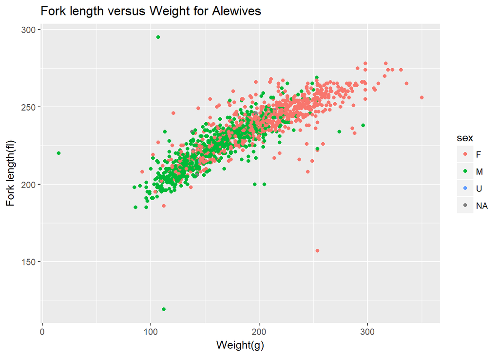

```r
ggplot(data= aw.df,mapping= aes(x=w,y=fl,colour=sex),position="jitter")+
  geom_point()+
  ggtitle("Fork length versus Weight for Alewives")+
  xlab("Weight(g)")+
  ylab("Fork length(fl)")
```

```r
library(lubridate)
```

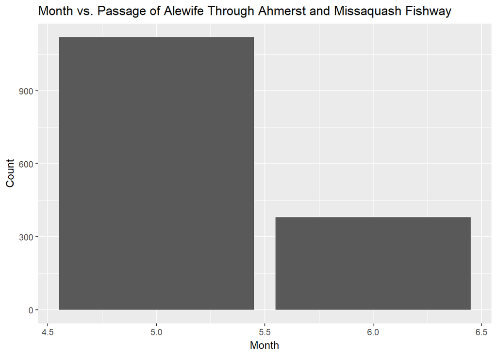

```r
aw.df %>%
  mutate(month=month(m,label=TRUE)) %>%
  ggplot(aes(x=m))+
  geom_bar()+
  ggtitle("Month vs. Passage of Alewife Through Ahmerst and Missaquash Fishway")+
  xlab("Month")+
  ylab("Count")
```

Graph showing the number of fish entering the system by date, and bars are separated by sex

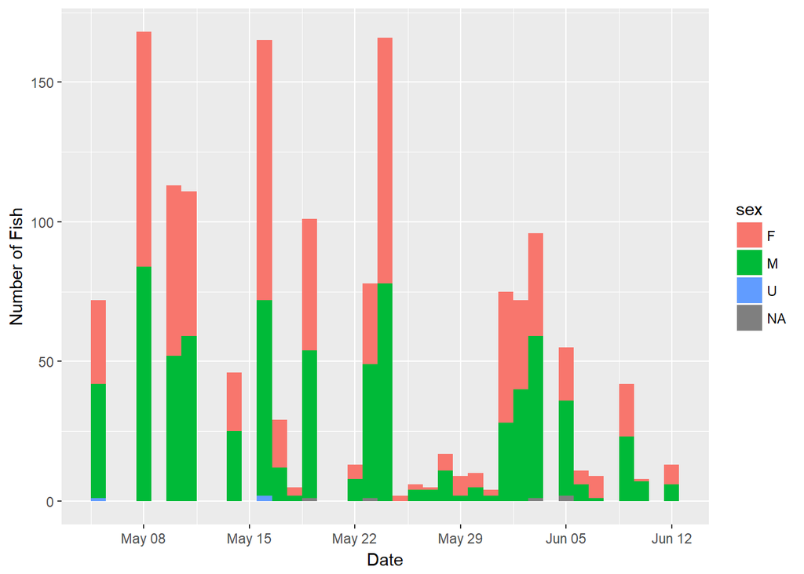

```r
aw.df <- aw.df %>%
  mutate(enter = make_date(y, m, d))

ggplot(aw.df, aes(enter))+
  geom_histogram(aes(fill = sex), binwidth = 1)+
  xlab("Date")+
  ylab("Number of Fish")
```

```r
aw.df <- aw.df %>%
  mutate(length = ntile(fl, 6))

View(aw.df)
```

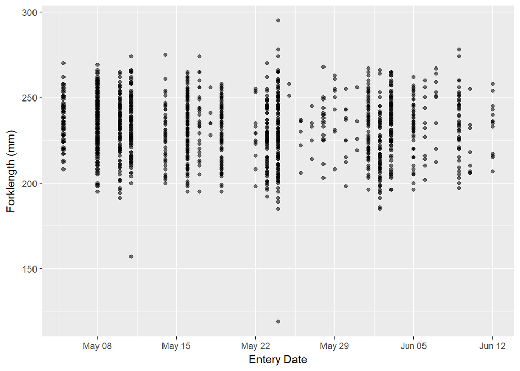

```r
ggplot(aw.df, aes(enter, fl, alpha = 1/10))+
  geom_point()+
  ylab("Forklength (mm)")+
  xlab("Entery Date")+
  theme(legend.position = 'none')
```

Change NA values to U

```r
aw.df.2 <- mutate(aw.df,sex = ifelse(sex %in% c("NA"),"U", sex))
```

Graph of the relationship between forklength and sex.

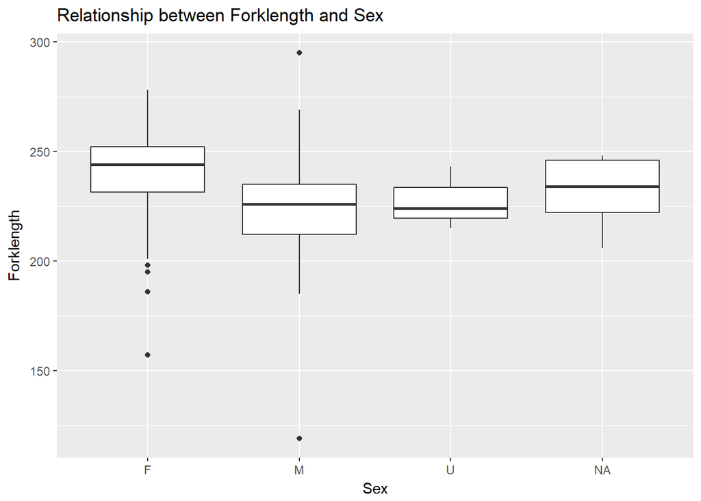

```r
ggplot(data=aw.df.2,mapping=aes(x=sex,y=fl))+
  geom_boxplot()+
  ggtitle("Relationship between Forklength and Sex")+
  xlab("Sex")+
  ylab("Forklength")
```

Graph the relationship between size (fl) and tagging location (site)

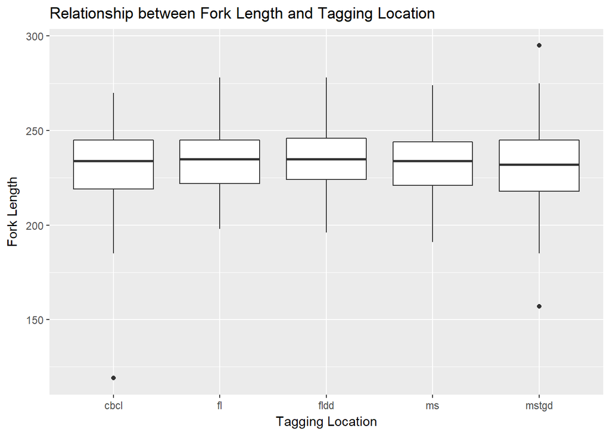

```r
ggplot(data = aw.df) +
  geom_boxplot(mapping = aes(x = site, y = fl)) +
  ggtitle("Relationship between Fork Length and Tagging Location") +
  ylab("Fork Length") +
  xlab("Tagging Location")
```

# **OUR RESEARCH QUESTIONS**

**1. Is there a relationship between forklength of fish and sex?**

Response variable -> forklength (normally distributed) Predictor variable -> sex

Using a Welsh two-sample t-test -> I know this isn’t the ideal test to perform, but it will determine if the two groups (male and female) have the same mean of forklength. If the t-test indicates that the mean is not the same, we can determine that the forklengths differ among sex

Create two datasets from aw.df; one with just female forklenghs and the other with just male forklengths

```r
newmodel.df <- select(aw.df, fl, sex)
female.df <- filter(newmodel.df, sex == "F")
male.df <- filter(newmodel.df, sex == "M")
female.df$sex = NULL
male.df$sex = NULL
colnames(female.df)[1] = "female.fl"
colnames(male.df)[1] = "male.fl"
```

We now want to create a new dataset by combining the forklength columns of male.df and female.df, but there’s an issue: male.df has 763 values and female.df has 730 values. So we first need to add 33 values of NA to the female dataset – I know there’s a “one-line code” way to do this but I couldn’t figure it out, so I did 33 seperate lines of code to add them all individually.

```r
female.df <- rbind(female.df, "731" = c(NA, NA))
female.df <- rbind(female.df, "731" = c(NA, NA))
female.df <- rbind(female.df, "731" = c(NA, NA))
female.df <- rbind(female.df, "731" = c(NA, NA))
female.df <- rbind(female.df, "731" = c(NA, NA))
female.df <- rbind(female.df, "731" = c(NA, NA))
female.df <- rbind(female.df, "731" = c(NA, NA))
female.df <- rbind(female.df, "731" = c(NA, NA))
female.df <- rbind(female.df, "731" = c(NA, NA))
female.df <- rbind(female.df, "731" = c(NA, NA))
female.df <- rbind(female.df, "731" = c(NA, NA))
female.df <- rbind(female.df, "731" = c(NA, NA))
female.df <- rbind(female.df, "731" = c(NA, NA))
female.df <- rbind(female.df, "731" = c(NA, NA))
female.df <- rbind(female.df, "731" = c(NA, NA))
female.df <- rbind(female.df, "731" = c(NA, NA))
female.df <- rbind(female.df, "731" = c(NA, NA))
female.df <- rbind(female.df, "731" = c(NA, NA))
female.df <- rbind(female.df, "731" = c(NA, NA))
female.df <- rbind(female.df, "731" = c(NA, NA))
female.df <- rbind(female.df, "731" = c(NA, NA))
female.df <- rbind(female.df, "731" = c(NA, NA))
female.df <- rbind(female.df, "731" = c(NA, NA))
female.df <- rbind(female.df, "731" = c(NA, NA))
female.df <- rbind(female.df, "731" = c(NA, NA))
female.df <- rbind(female.df, "731" = c(NA, NA))
female.df <- rbind(female.df, "731" = c(NA, NA))
female.df <- rbind(female.df, "731" = c(NA, NA))
female.df <- rbind(female.df, "731" = c(NA, NA))
female.df <- rbind(female.df, "731" = c(NA, NA))
female.df <- rbind(female.df, "731" = c(NA, NA))
female.df <- rbind(female.df, "731" = c(NA, NA))
female.df <- rbind(female.df, "731" = c(NA, NA))
```

Create the new dataset with the columns male.fl and female.fl

```r
male.df$female.fl <- female.df$female.fl
female.fl <- male.df$female.fl
male.fl <- male.df$male.fl
```

Now we can run the t.test

```r
t.test(female.fl, male.fl)
```

```
##
##  Welch Two Sample t-test
##
## data:  female.fl and male.fl
## t = 20.423, df = 1486.7, p-value < 2.2e-16
## alternative hypothesis: true difference in means is not equal to 0
## 95 percent confidence interval:
##  14.99193 18.17771
## sample estimates:
## mean of x mean of y
##  240.7699  224.1850
```

**3.Is there a difference between size of fish and tagging location?**

Response variable -> forklength of fish (normally distributed) Predictor variable -> site

Creating a data frame with just the information I will need for the model (not necessary but easier for me to see)

```r
aw.sites <- select(aw.df, fl, site)
```

Test to see if ANOVA of this data frame works

```r
aov(fl ~ site, aw.sites)
```

```
## Call:
##    aov(formula = fl ~ site, data = aw.sites)
##
## Terms:
##                     site Residuals
## Sum of Squares    1450.1  469076.2
## Deg. of Freedom        4      1495
##
## Residual standard error: 17.71337
## Estimated effects may be unbalanced
## 1 observation deleted due to missingness
```

Creating linear model to look at relationship between forklength (fl) and site

```r
mod.site <- lm(fl ~ site, aw.sites)
```

Doing ANOVA on the model created above to see whether forklength is different by location

```r
anova(mod.site)
```

```
## Analysis of Variance Table
##
## Response: fl
##             Df Sum Sq Mean Sq F value Pr(>F)
## site         4   1450  362.53  1.1554 0.3288
## Residuals 1495 469076  313.76
```

Based on the ANOVA there is not evidence to suggest that fish of different size prefer different fishways

Summary of my model

```r
summary(mod.site)
```

```
##
## Call:
## lm(formula = fl ~ site, data = aw.sites)
##
## Residuals:
##      Min       1Q   Median       3Q      Max
## -112.664  -12.537    1.063   13.336   63.463
##
## Coefficients:
##             Estimate Std. Error t value Pr(>|t|)
## (Intercept) 231.6644     0.8493 272.774   <2e-16 ***
## sitefl        1.3581     2.0608   0.659   0.5100
## sitefldd      2.5633     1.4567   1.760   0.0787 .
## sitems        1.2726     1.4282   0.891   0.3730
## sitemstgd    -0.1274     1.1540  -0.110   0.9121
## ---
## Signif. codes:  0 '***' 0.001 '**' 0.01 '*' 0.05 '.' 0.1 ' ' 1
##
## Residual standard error: 17.71 on 1495 degrees of freedom
##   (1 observation deleted due to missingness)
## Multiple R-squared:  0.003082,   Adjusted R-squared:  0.0004146
## F-statistic: 1.155 on 4 and 1495 DF,  p-value: 0.3288
```

Residual plots of this model

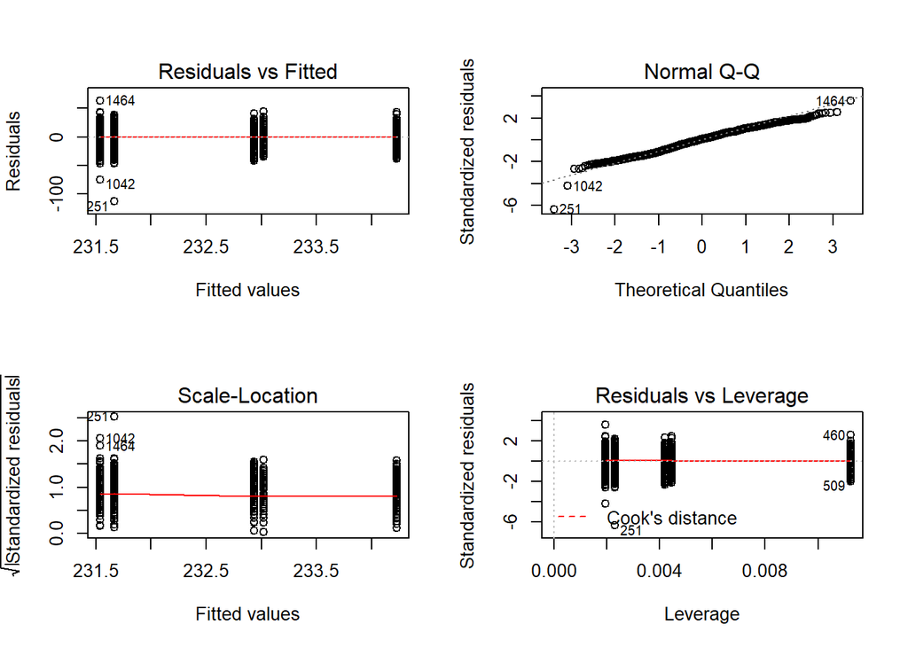

```r
par(mfrow = c(2, 2))
plot(mod.site)
```

```r
mod.site2 <- lm(fl ~ site + sex + h, aw.df)
```

```r
anova(mod.site2)
```

```
## Analysis of Variance Table
##
## Response: fl
##             Df Sum Sq Mean Sq  F value Pr(>F)
## site         4   1506     377   1.5427 0.1874
## sex          2 104576   52288 214.2348 <2e-16 ***
## h            1    280     280   1.1464 0.2845
## Residuals 1487 362930     244
## ---
## Signif. codes:  0 '***' 0.001 '**' 0.01 '*' 0.05 '.' 0.1 ' ' 1
```

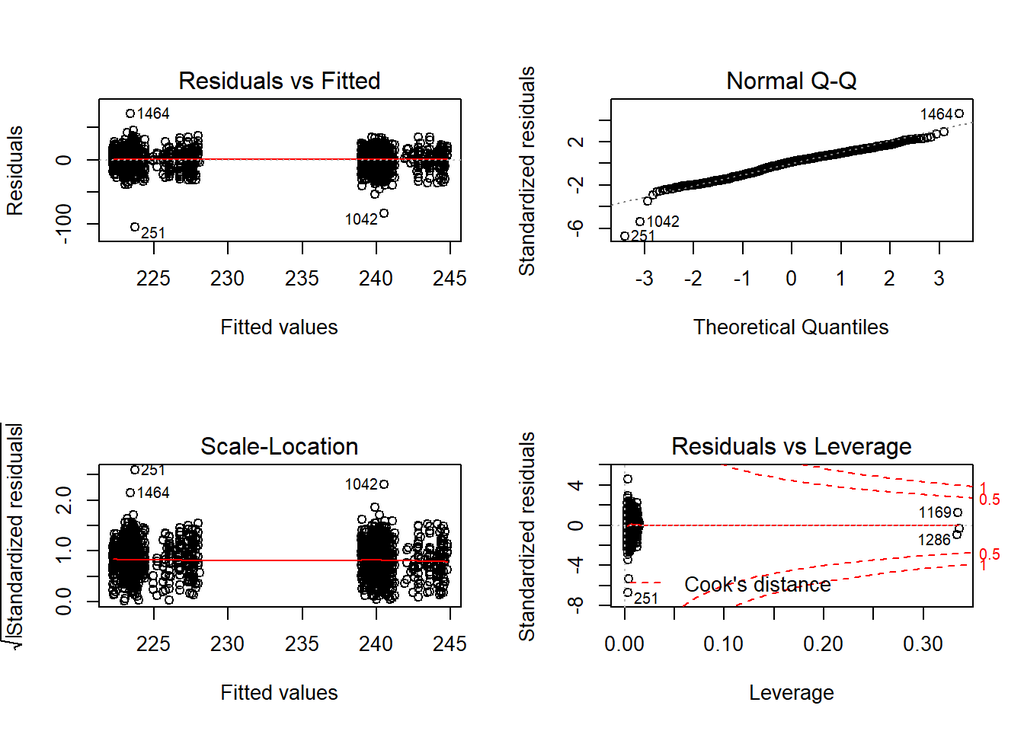

```r
par(mfrow = c(2, 2))
plot(mod.site2)
```

Model seems to fit pretty well, the values are evenly distributed around zero and Q-Q plot follows the line with a bit of spread at the top and bottom

**4. Is there a difference between migration time and amount of fish observed?**

I think we should use a poisson distribution as we have different times of day in which fish were captured and a posssion test is used for count data. We want to compare whether the abundance of Alewife differs between different hours of the day, and this measure is a discrete variable. The fish are assumed to be distibuted randomly and independently and samples of equal size were assumed to be taken randomly.

Create a histogram to compare abundance.

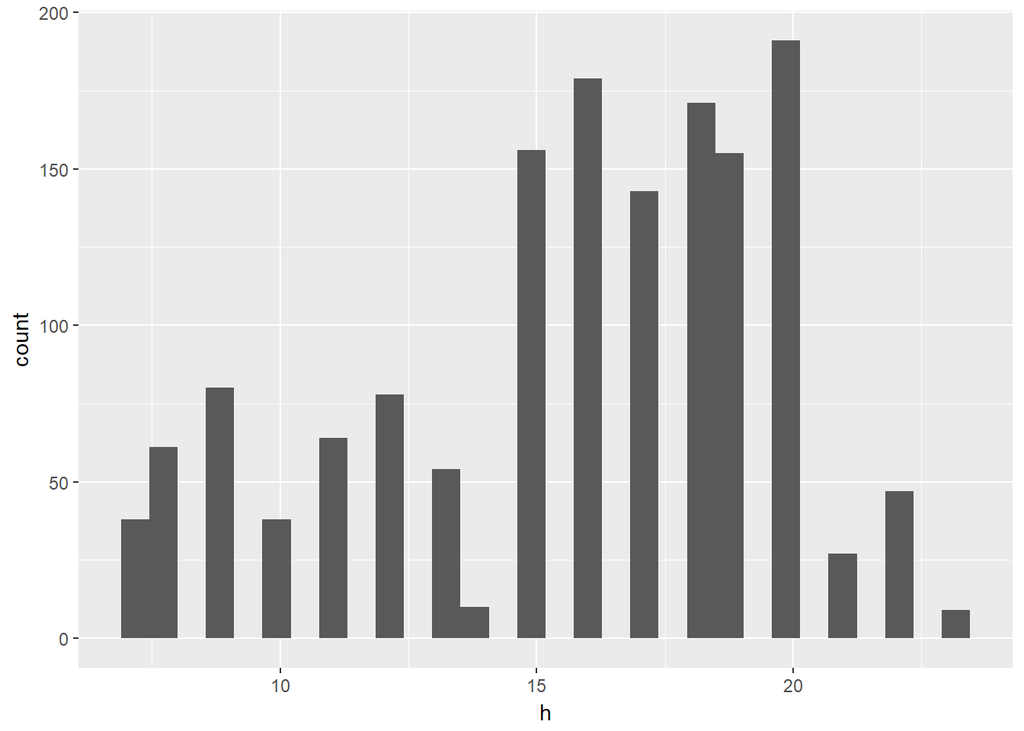

```r
ggplot(data=aw.df,aes(h))+
  geom_histogram()
```

Count the Alewife Present at each hour

```r
data.frame(table(aw.df$h))
```

```
##    Var1 Freq
## 1     7   38
## 2     8   61
## 3     9   80
## 4    10   38
## 5    11   64
## 6    12   78
## 7    13   54
## 8    14   10
## 9    15  156
## 10   16  179
## 11   17  143
## 12   18  171
## 13   19  155
## 14   20  191
## 15   21   27
## 16   22   47
## 17   23    9
```

Fit the model

I created a data frame that contains the frequncy of alweife captured at each hour. The frequency needs to be used in the poisson glm.

```r
aw.df.2 <- aw.df %>% group_by(h) %>%tally()
```

Use poisson distribution.

I am not sure how to interpret the coefficients.

There will be a 3.1% increase in the number of fish caught for each increase in hour throughout the day?

There appears to be a statistically significant difference between different hours of the day and the number of Alewife captured?

```r
p1 <- glm(n~h,family="poisson",data=aw.df.2)
summary(p1)
```

```
##
## Call:
## glm(formula = n ~ h, family = "poisson", data = aw.df.2)
##
## Deviance Residuals:
##     Min       1Q   Median       3Q      Max
## -12.655   -4.705   -1.138    5.219    8.252
##
## Coefficients:
##             Estimate Std. Error z value Pr(>|z|)
## (Intercept) 4.006202   0.087388  45.844  < 2e-16 ***
## h           0.030871   0.005305   5.819 5.92e-09 ***
## ---
## Signif. codes:  0 '***' 0.001 '**' 0.01 '*' 0.05 '.' 0.1 ' ' 1
##
## (Dispersion parameter for poisson family taken to be 1)
##
##     Null deviance: 753.16  on 16  degrees of freedom
## Residual deviance: 719.06  on 15  degrees of freedom
## AIC: 824.94
##
## Number of Fisher Scoring iterations: 5
```

Check assumptions

Residuals versus fitted values: The indendence of error assumption can’t be followed, as some values appear to influence one another. Do you need this in a poission model because the variance is equal to the mean?

The residuals are normally distributed.

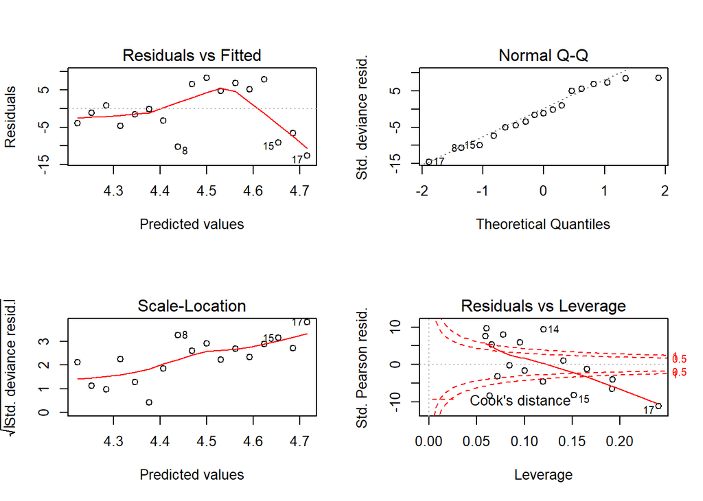

```r
par(mfrow=c(2,2))
plot(p1)
```

**5. Is there a relationship between fork length and weight? If yes, create a model**

Using aw.df dataset created above from alewife17.df. Subset aw.df to remove NA and match each weight to a fork length

```r
temp.df <- subset(aw.df, !is.na(w) & !is.na(fl))
```

Create dataset with just the columns I need

```r
aw.df2 <- select(temp.df, fl, w, sex)
subset(aw.df2, !is.na(w) & !is.na(fl))
```

[output not shown]

[output cut: 1404 more lines]

```r
aw.df2$w <- as.integer(aw.df2$w)
```

As proven above in plot, there is a difference between males and females, so I’ll create two seperate datsets

```r
aw.dff <- filter(aw.df2, sex == "F")
aw.dfm <- filter(aw.df2, sex == "M")
```

Working with Male data, plot fork length vs. weight and fit a linear model

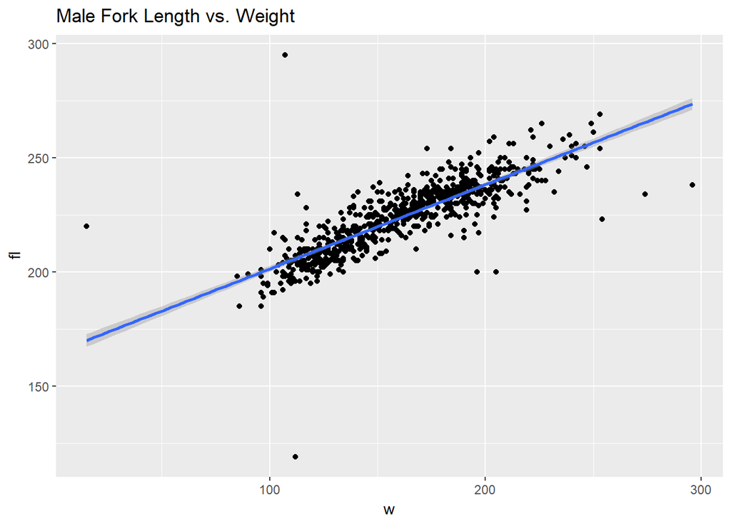

```r
ggplot(aw.dfm, aes(x = w, y = fl)) +
  geom_point()+
  geom_smooth(method = lm) +
  ggtitle("Male Fork Length vs. Weight")
```

Looking at summary of linear model to create equation

```r
lmm <- lm(fl ~ w, data = aw.dfm)
summary(lmm)
```

```
##
## Call:
## lm(formula = fl ~ w, data = aw.dfm)
##
## Residuals:
##     Min      1Q  Median      3Q     Max
## -86.786  -4.530  -0.056   4.106  91.057
##
## Coefficients:
##              Estimate Std. Error t value Pr(>|t|)
## (Intercept) 1.645e+02  1.561e+00  105.38   <2e-16 ***
## w           3.685e-01  9.481e-03   38.87   <2e-16 ***
## ---
## Signif. codes:  0 '***' 0.001 '**' 0.01 '*' 0.05 '.' 0.1 ' ' 1
##
## Residual standard error: 8.984 on 715 degrees of freedom
## Multiple R-squared:  0.6788, Adjusted R-squared:  0.6783
## F-statistic:  1511 on 1 and 715 DF,  p-value: < 2.2e-16
```

This summary table shows that the y-intercept = 164.5 and the slope = 0.3685, making the equation: Y = 0.3685x + 164.5

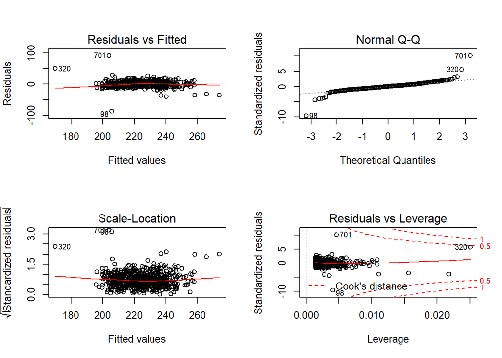

```r
par(mfrow=c(2,2))
plot(lmm)
```

Working with Female data, plot fork length vs. weight and fit a linear model

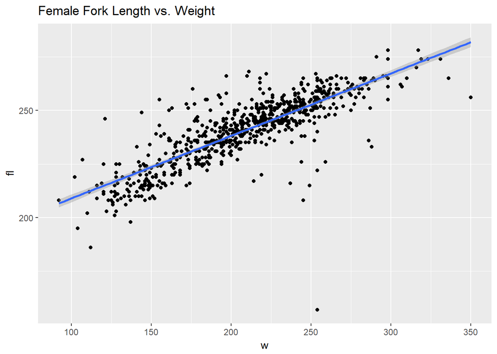

```r
ggplot(aw.dff, aes(x = w, y = fl)) +
  geom_point() +
  geom_smooth(method = lm) +
  ggtitle("Female Fork Length vs. Weight")
```

```r
lmf <- lm(fl ~ w, data = aw.dff)
summary(lmf)
```

```
##
## Call:
## lm(formula = fl ~ w, data = aw.dff)
##
## Residuals:
##     Min      1Q  Median      3Q     Max
## -96.879  -4.630   0.145   4.544  30.854
##
## Coefficients:
##              Estimate Std. Error t value Pr(>|t|)
## (Intercept) 1.799e+02  1.677e+00  107.26   <2e-16 ***
## w           2.912e-01  7.882e-03   36.95   <2e-16 ***
## ---
## Signif. codes:  0 '***' 0.001 '**' 0.01 '*' 0.05 '.' 0.1 ' ' 1
##
## Residual standard error: 9.204 on 692 degrees of freedom
## Multiple R-squared:  0.6636, Adjusted R-squared:  0.6631
## F-statistic:  1365 on 1 and 692 DF,  p-value: < 2.2e-16
```

This summary table shows that the y-intercept = 179.9 and the slope = 0.2912, making the equation: Y = 0.2912x + 179.9

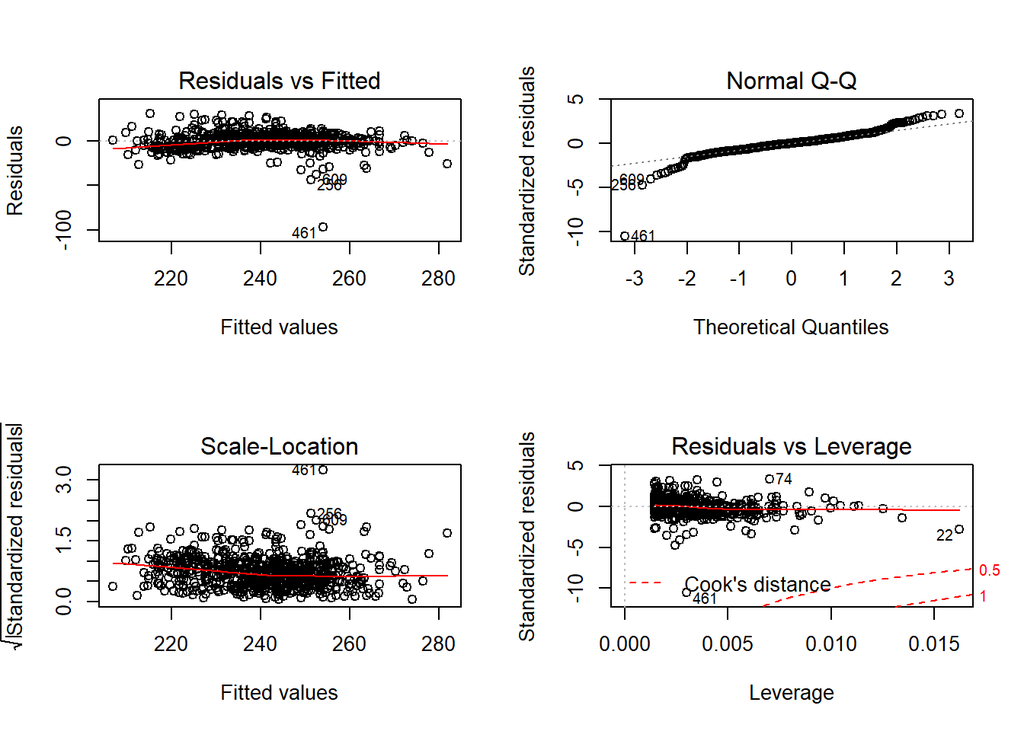

```r
par(mfrow=c(2,2))
plot(lmf)
```

Usually for fish, fork length vs. weight creates an exponential relationship because fork length increases in 2D and weight increases in 3D. Since this is the usual trend, I wanted to log transform the data (turns exponential data into linear data) and compare the linear models to see which is more accurate

Males:

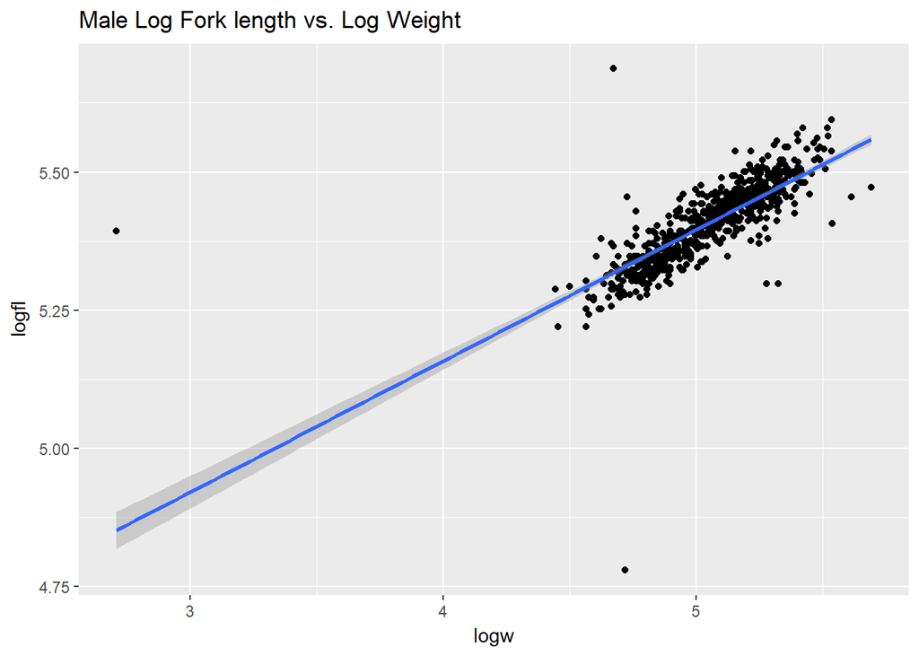

```r
aw.dfml <- aw.dfm %>%
  mutate(logfl = log(fl), logw = log(w))

ggplot(aw.dfml, aes(x = logw, y = logfl)) +
  geom_point() +
  geom_smooth(method = lm) +
  ggtitle("Male Log Fork length vs. Log Weight")
```

```r
lmml <- lm(logfl ~ logw, data = aw.dfml)
summary(lmml)
```

```
##
## Call:
## lm(formula = logfl ~ logw, data = aw.dfml)
##
## Residuals:
##      Min       1Q   Median       3Q      Max
## -0.54927 -0.02097  0.00123  0.01894  0.54222
##
## Coefficients:
##             Estimate Std. Error t value Pr(>|t|)
## (Intercept) 4.208896   0.036535  115.20   <2e-16 ***
## logw        0.237258   0.007221   32.86   <2e-16 ***
## ---
## Signif. codes:  0 '***' 0.001 '**' 0.01 '*' 0.05 '.' 0.1 ' ' 1
##
## Residual standard error: 0.04585 on 715 degrees of freedom
## Multiple R-squared:  0.6016, Adjusted R-squared:  0.601
## F-statistic:  1080 on 1 and 715 DF,  p-value: < 2.2e-16
```

This summary table shows that the y-intercept = 4.208896 and the slope = 0.237258, making the equation: Y = 0.237258x + 4.208896

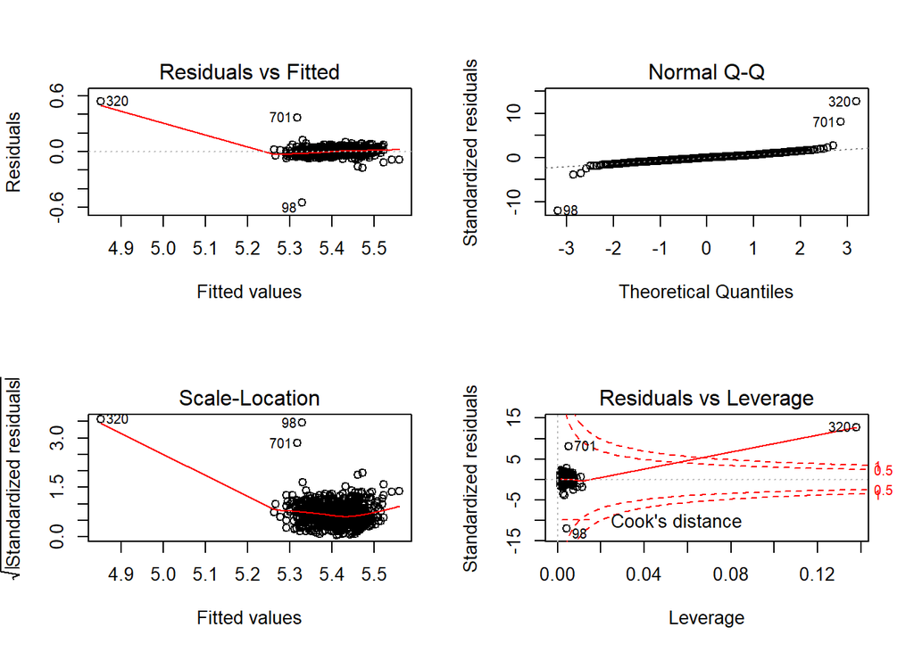

```r
par(mfrow=c(2,2))
plot(lmml)
```

Females:

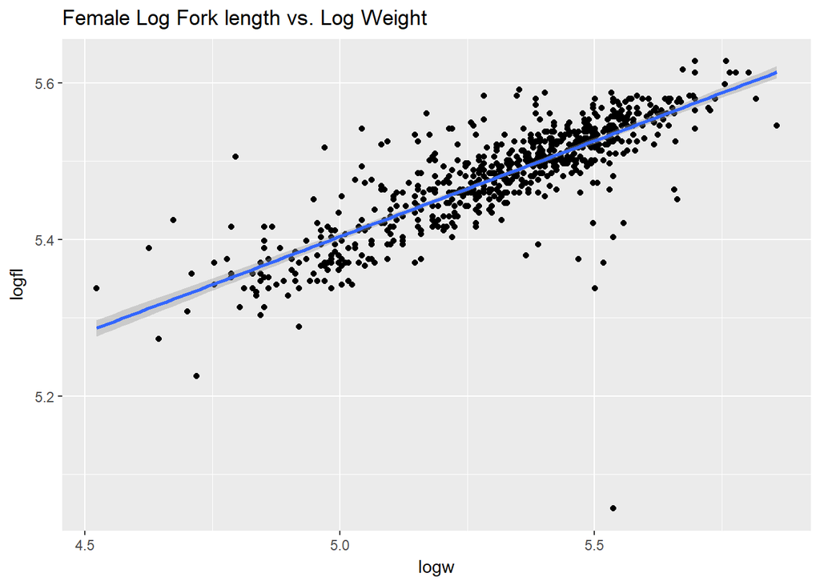

```r
aw.dffl <- aw.dff %>%
  mutate(logfl = log(fl), logw = log(w))

ggplot(aw.dffl, aes(x = logw, y = logfl)) +
  geom_point() +
  geom_smooth(method = lm) +
  ggtitle("Female Log Fork length vs. Log Weight")
```

```r
lmfl <- lm(logfl ~ logw, data = aw.dffl)
summary(lmfl)
```

```
##
## Call:
## lm(formula = logfl ~ logw, data = aw.dffl)
##
## Residuals:
##      Min       1Q   Median       3Q      Max
## -0.47901 -0.01757  0.00040  0.01794  0.15157
##
## Coefficients:
##             Estimate Std. Error t value Pr(>|t|)
## (Intercept) 4.179992   0.035179   118.8   <2e-16 ***
## logw        0.244750   0.006614    37.0   <2e-16 ***
## ---
## Signif. codes:  0 '***' 0.001 '**' 0.01 '*' 0.05 '.' 0.1 ' ' 1
##
## Residual standard error: 0.0393 on 692 degrees of freedom
## Multiple R-squared:  0.6643, Adjusted R-squared:  0.6638
## F-statistic:  1369 on 1 and 692 DF,  p-value: < 2.2e-16
```

This summary table shows that the y-intercept = 4.179992 and the slope = 0.24475, making the equation: Y = 0.24475x + 4.179992

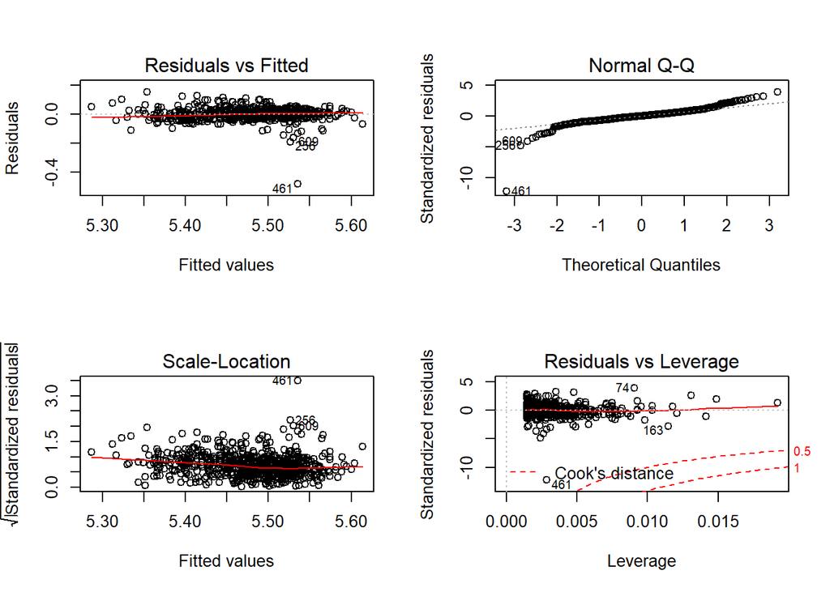

```r
par(mfrow=c(2,2))
plot(lmfl)
```

To recap, we have the data separated into males and females, and we have a total of 4 linear model equations:

1. Male fl vs. w Y = 0.3685x + 164.5 P-value = 2e-16
2. Male logfl vs logw Y = 0.237258x + 4.208896 P-value = 2e-16
3. Female fl vs. w Y = 0.2912x + 179.9 P-value = 2e-16
4. Female logfl vs. logw Y = 0.24475x + 4.179992 P-value = 2e-16